# Education inequality

## Introduction

This project addresses inequality of educational opportunity in U.S. high schools. Here we will focus on average student performance on the ACT or SAT exams that students take as part of the college application process.

We expect a range of school performance on these exams, but is school performance predicted by socioeconomic factors?

$\rightarrow$ Complete the introduction with a description of the problem you are addressing. The introduction should include at least two paragraphs that describe (1) the general problem you are addressing and (2) the specific questions you are asking in this project.

## Data Collection

This project utilizes two data sets. The primary data set is the EdGap data set from [EdGap.org](https://www.edgap.org/#5/37.875/-96.987). This data set from 2016 includes information about average ACT or SAT scores for schools and several socioeconomic characteristics of the school district. The secondary data set is basic information about each school from the [National Center for Education Statistics](https://nces.ed.gov/ccd/pubschuniv.asp).

### EdGap data

All socioeconomic data (household income, unemployment, adult educational attainment, and family structure) are from the Census Bureau’s American Community Survey.

[EdGap.org](https://www.edgap.org/#5/37.875/-96.987) report that ACT and SAT score data is from each state’s department of education or some other public data release. The nature of the other public data release is not known.

The quality of the census data and the department of education data can be assumed to be reasonably high.

[EdGap.org](https://www.edgap.org/#5/37.875/-96.987) do not indicate that they processed the data in any way. The data were assembled by the [EdGap.org](https://www.edgap.org/#5/37.875/-96.987) team, so there is always the possibility for human error. Given the public nature of the data, we would be able to consult the original data sources to check the quality of the data if we had any questions.

### School information data

The school information data is from the [National Center for Education Statistics](https://nces.ed.gov/ccd/pubschuniv.asp). This data set consists of basic identifying information about schools and can be assumed to be of reasonably high quality. As for the EdGap.org data, the school information data is public, so we would be able to consult the original data sources to check the quality of the data if we had any questions.

### Data ethics

#### Data Science Ethics Checklist

**A. Problem Formulation**

- **A.1 Well-Posed Problem**: Is it possible to answer our question with data? Is the problem well-posed?

**B. Data Collection**

- **B.1 Informed consent**: If there are human subjects, have they given informed consent, where subjects affirmatively opt-in and have a clear understanding of the data uses to which they consent?
- **B.2 Collection bias**: Have we considered sources of bias that could be introduced during data collection and survey design and taken steps to mitigate those?
- **B.3 Limit PII exposure**: Have we considered ways to minimize exposure of personally identifiable information (PII) for example through anonymization or not collecting information that isn’t relevant for analysis?
- **B.4 Downstream bias mitigation**: Have we considered ways to enable testing downstream results for biased outcomes (e.g., collecting data on protected group status like race or gender)?

**C. Data Storage**

- **C.1 Data security**: Do we have a plan to protect and secure data (e.g., encryption at rest and in transit, access controls on internal users and third parties, access logs, and up-to-date software)?
- **C.2 Right to be forgotten**: Do we have a mechanism through which an individual can request their personal information be removed?
- **C.3 Data retention plan**: Is there a schedule or plan to delete the data after it is no longer needed?

**D. Analysis**

- **D.1 Missing perspectives**: Have we sought to address blindspots in the analysis through engagement with relevant stakeholders (e.g., checking assumptions and discussing implications with affected communities and subject matter experts)?
- **D.2 Dataset bias**: Have we examined the data for possible sources of bias and taken steps to mitigate or address these biases (e.g., stereotype perpetuation, confirmation bias, imbalanced classes, or omitted confounding variables)?
- **D.3 Honest representation**: Are our visualizations, summary statistics, and reports designed to honestly represent the underlying data?
- **D.4 Privacy in analysis**: Have we ensured that data with PII are not used or displayed unless necessary for the analysis?
- **D.5 Auditability**: Is the process of generating the analysis well documented and reproducible if we discover issues in the future?

**E. Modeling**

- **E.1 Proxy discrimination**: Have we ensured that the model does not rely on variables or proxies for variables that are unfairly discriminatory?
- **E.2 Fairness across groups**: Have we tested model results for fairness with respect to different affected groups (e.g., tested for disparate error rates)?
- **E.3 Metric selection**: Have we considered the effects of optimizing for our defined metrics and considered additional metrics?
- **E.4 Explainability**: Can we explain in understandable terms a decision the model made in cases where a justification is needed?
- **E.5 Communicate bias**: Have we communicated the shortcomings, limitations, and biases of the model to relevant stakeholders in ways that can be generally understood?

**F. Deployment**

- **F.1 Redress**: Have we discussed with our organization a plan for response if users are harmed by the results (e.g., how does the data science team evaluate these cases and update analysis and models to prevent future harm)?
- **F.2 Roll back**: Is there a way to turn off or roll back the model in production if necessary?
- **F.3 Concept drift**: Do we test and monitor for concept drift to ensure the model remains fair over time?
- **F.4 Unintended use**: Have we taken steps to identify and prevent unintended uses and abuse of the model and do we have a plan to monitor these once the model is deployed?

*Data Science Ethics Checklist generated with [deon](http://deon.drivendata.org).*

We will discuss these issues in class.

## Data Preparation

### Load necessary packages

```r
#readxl lets us read Excel files
library(readxl)
#GGally has a nice pairs plotting function
library(GGally)
#skimr provides a nice summary of a data set
library(skimr)
#leaps will be used for model selection
library(leaps)
#kableExtra will be used to make tables in the html document
library(kableExtra)
#latex2exp lets us use LaTex in ggplot
library(latex2exp)
#tidyverse contains packages we will use for processing and plotting data
library(tidyverse)
```

### Load the data

#### Load the EdGap set

$\rightarrow$ Load the data set contained in the file `EdGap_data.xlsx` and name the data frame `edgap`.

```r
edgap <- read_excel("EdGap_data.xlsx")
```

### Explore the contents of the data set

$\rightarrow$ Look at the first few rows of the data frame.

```r
head(edgap, n = 5)
```

```
## # A tibble: 5 × 7
##   `NCESSCH School ID` `CT Unemployment Rate` `CT Pct Adults w…` `CT Pct Childr…`
##                 <dbl>                  <dbl>              <dbl>            <dbl>
## 1        100001600143                 0.118               0.445            0.346
## 2        100008000024                 0.0640              0.663            0.768
## 3        100008000225                 0.0565              0.702            0.713
## 4        100017000029                 0.0447              0.692            0.641
## 5        100018000040                 0.0770              0.640            0.834
## # … with 3 more variables: `CT Median Household Income` <dbl>,
## #   `School ACT average (or equivalent if SAT score)` <dbl>,
## #   `School Pct Free and Reduced Lunch` <dbl>
```

Use the `View` function to explore the full data set.

```r
View(edgap)
```

#### Load school information data

$\rightarrow$ Load the data set contained in the file `ccd_sch_029_1617_w_1a_11212017.csv` and name the data frame `school_info`.

```r
school_info <- read_csv("ccd_sch_029_1617_w_1a_11212017.csv")
```

$\rightarrow$ Look at the first few rows of the data frame.

```r
head(school_info, n = 5)
```

```
## # A tibble: 5 × 65
##   SCHOOL_YEAR FIPST STATENAME ST    SCH_NAME      LEA_NAME STATE_AGENCY_NO UNION
##   <chr>       <chr> <chr>     <chr> <chr>         <chr>    <chr>           <chr>
## 1 2016-2017   01    ALABAMA   AL    Sequoyah Sch… Alabama… 01              <NA>
## 2 2016-2017   01    ALABAMA   AL    Camps         Alabama… 01              <NA>
## 3 2016-2017   01    ALABAMA   AL    Det Ctr       Alabama… 01              <NA>
## 4 2016-2017   01    ALABAMA   AL    Wallace Sch … Alabama… 01              <NA>
## 5 2016-2017   01    ALABAMA   AL    McNeel Sch -… Alabama… 01              <NA>
## # … with 57 more variables: ST_LEAID <chr>, LEAID <chr>, ST_SCHID <chr>,
## #   NCESSCH <chr>, SCHID <chr>, MSTREET1 <chr>, MSTREET2 <chr>, MSTREET3 <lgl>,
## #   MCITY <chr>, MSTATE <chr>, MZIP <chr>, MZIP4 <chr>, LSTREET1 <chr>,
## #   LSTREET2 <chr>, LSTREET3 <lgl>, LCITY <chr>, LSTATE <chr>, LZIP <chr>,
## #   LZIP4 <chr>, PHONE <chr>, WEBSITE <chr>, SY_STATUS <dbl>,
## #   SY_STATUS_TEXT <chr>, UPDATED_STATUS <dbl>, UPDATED_STATUS_TEXT <chr>,
## #   EFFECTIVE_DATE <chr>, SCH_TYPE_TEXT <chr>, SCH_TYPE <dbl>, …
```

### Check for a tidy data frame

In a tidy data set, each column is a variable or id and each row is an observation. We again start by looking at the head of the data frame to determine if the data frame is tidy.

#### EdGap data

```r
head(edgap)
```

```
## # A tibble: 6 × 7
##   `NCESSCH School ID` `CT Unemployment Rate` `CT Pct Adults w…` `CT Pct Childr…`
##                 <dbl>                  <dbl>              <dbl>            <dbl>
## 1        100001600143                 0.118               0.445            0.346
## 2        100008000024                 0.0640              0.663            0.768
## 3        100008000225                 0.0565              0.702            0.713
## 4        100017000029                 0.0447              0.692            0.641
## 5        100018000040                 0.0770              0.640            0.834
## 6        100019000050                 0.0801              0.673            0.483
## # … with 3 more variables: `CT Median Household Income` <dbl>,
## #   `School ACT average (or equivalent if SAT score)` <dbl>,
## #   `School Pct Free and Reduced Lunch` <dbl>
```

The units of observation are the schools. Each school occupies one row of the data frame, which is what we want for the rows.

$\rightarrow$ What variables are present? What types of variables are present?

```r
skim(edgap)
```

Data summary

| Name | edgap |
| --- | --- |
| Number of rows | 7986 |
| Number of columns | 7 |
| _______________________ |  |
| Column type frequency: |  |
| numeric | 7 |
| ________________________ |  |
| Group variables | None |

**Variable type: numeric**

| skim_variable | n_missing | complete_rate | mean | sd | p0 | p25 | p50 | p75 | p100 | hist |
| --- | --- | --- | --- | --- | --- | --- | --- | --- | --- | --- |
| NCESSCH School ID | 0 | 1 | 3.321869e+11 | 1.323638e+11 | 1.000016e+11 | 2.105340e+11 | 3.600085e+11 | 4.226678e+11 | 5.60583e+11 | ▇▆▆▅▇ |
| CT Unemployment Rate | 14 | 1 | 1.000000e-01 | 6.000000e-02 | 0.000000e+00 | 6.000000e-02 | 9.000000e-02 | 1.200000e-01 | 5.90000e-01 | ▇▃▁▁▁ |
| CT Pct Adults with College Degree | 13 | 1 | 5.700000e-01 | 1.700000e-01 | 9.000000e-02 | 4.500000e-01 | 5.500000e-01 | 6.800000e-01 | 1.00000e+00 | ▁▅▇▅▂ |
| CT Pct Childre In Married Couple Family | 25 | 1 | 6.300000e-01 | 2.000000e-01 | 0.000000e+00 | 5.200000e-01 | 6.700000e-01 | 7.800000e-01 | 1.00000e+00 | ▁▂▅▇▃ |
| CT Median Household Income | 20 | 1 | 5.202691e+04 | 2.422806e+04 | 3.589000e+03 | 3.659725e+04 | 4.683350e+04 | 6.136925e+04 | 2.26181e+05 | ▇▆▁▁▁ |
| School ACT average (or equivalent if SAT score) | 0 | 1 | 2.018000e+01 | 2.600000e+00 | -3.070000e+00 | 1.860000e+01 | 2.040000e+01 | 2.191000e+01 | 3.23600e+01 | ▁▁▂▇▁ |
| School Pct Free and Reduced Lunch | 0 | 1 | 4.200000e-01 | 2.400000e-01 | -5.000000e-02 | 2.400000e-01 | 3.800000e-01 | 5.800000e-01 | 1.00000e+00 | ▃▇▆▃▂ |

$\rightarrow$ Is the `edgap` data frame tidy?

Yes, each column is a variable or id and each row is an observation, so the data frame is tidy.

#### School information data

We again start by looking at the head of the data frame to determine if the data frame is tidy.

```r
head(school_info)
```

```
## # A tibble: 6 × 65
##   SCHOOL_YEAR FIPST STATENAME ST    SCH_NAME      LEA_NAME STATE_AGENCY_NO UNION
##   <chr>       <chr> <chr>     <chr> <chr>         <chr>    <chr>           <chr>
## 1 2016-2017   01    ALABAMA   AL    Sequoyah Sch… Alabama… 01              <NA>
## 2 2016-2017   01    ALABAMA   AL    Camps         Alabama… 01              <NA>
## 3 2016-2017   01    ALABAMA   AL    Det Ctr       Alabama… 01              <NA>
## 4 2016-2017   01    ALABAMA   AL    Wallace Sch … Alabama… 01              <NA>
## 5 2016-2017   01    ALABAMA   AL    McNeel Sch -… Alabama… 01              <NA>
## 6 2016-2017   01    ALABAMA   AL    Alabama Yout… Alabama… 01              <NA>
## # … with 57 more variables: ST_LEAID <chr>, LEAID <chr>, ST_SCHID <chr>,
## #   NCESSCH <chr>, SCHID <chr>, MSTREET1 <chr>, MSTREET2 <chr>, MSTREET3 <lgl>,
## #   MCITY <chr>, MSTATE <chr>, MZIP <chr>, MZIP4 <chr>, LSTREET1 <chr>,
## #   LSTREET2 <chr>, LSTREET3 <lgl>, LCITY <chr>, LSTATE <chr>, LZIP <chr>,
## #   LZIP4 <chr>, PHONE <chr>, WEBSITE <chr>, SY_STATUS <dbl>,
## #   SY_STATUS_TEXT <chr>, UPDATED_STATUS <dbl>, UPDATED_STATUS_TEXT <chr>,
## #   EFFECTIVE_DATE <chr>, SCH_TYPE_TEXT <chr>, SCH_TYPE <dbl>, …
```

It is more difficult to assess whether this data frame is tidy because of the large number of columns with confusing names.

We have 65 columns, but many of the columns are identifying features of the school and are irrelevant for the analysis. We will select a subset of columns and do the analysis on the subset.

#### Select a subset of columns

We want to select the following variables:

| name | description |
| --- | --- |
| NCESSCH | NCES School ID |
| MSTATE | State name |
| MZIP | Zip code |
| SCH_TYPE_TEXT | School type |
| LEVEL | LEVEL |

$\rightarrow$ Use the `select` function to select these columns from the data frame.

```r
#We redefine the data frame to be the smaller version
school_info <- school_info %>%
  select(NCESSCH,MSTATE,MZIP,SCH_TYPE_TEXT,LEVEL)
```

$\rightarrow$ Examine the head of the new, smaller data frame

```r
head(school_info)
```

```
## # A tibble: 6 × 5
##   NCESSCH      MSTATE MZIP  SCH_TYPE_TEXT      LEVEL
##   <chr>        <chr>  <chr> <chr>              <chr>
## 1 010000200277 AL     35220 Alternative School High
## 2 010000201667 AL     36057 Alternative School High
## 3 010000201670 AL     36057 Alternative School High
## 4 010000201705 AL     36057 Alternative School High
## 5 010000201706 AL     35206 Alternative School High
## 6 010000201876 AL     35080 Regular School     Not applicable
```

$\rightarrow$ Is the data frame tidy?

Yes, each column is a variable or id and each row is an observation, so the data frame is tidy.

### Further exploration of basic properties

#### EdGap data

$\rightarrow$ How many observations are in the EdGap data set?

```r
nrow(edgap)
```

```
## [1] 7986
```

#### School information data

$\rightarrow$ How many observations are in the school information data set?

```r
nrow(school_info)
```

```
## [1] 102181
```

### Data cleaning

#### Rename variables

In any analysis, we might rename the variables in the data frame to make them easier to work with. We have seen that the variable names in the `edgap` data frame allow us to understand them, but they can be improved. In contrast, many of the variables in the `school_info` data frame have confusing names.

Importantly, we should be thinking ahead to joining the two data frames based on the school ID. To facilitate this join, we should give the school ID column the same name in each data frame.

#### EdGap data

$\rightarrow$ View the column names for the EdGap data

To follow best practices, we should

1. Use all lowercase letters in variable names.
2. Use underscores `_` between words in a variable name. Do not use blank spaces, as they have done.
3. Do not use abbreviations, e.g. `Pct`, that can easily be written out.
4. Be consistent with naming structure across variables. For example, the descriptions `rate`, `percent`, `median`, and `average` should all either be at the beginning or end of the name.

We will use the `rename` function from the `dplyr` package to rename the columns.

```r
#The new name for the column is on the left of the =

edgap <- edgap %>%
  rename(id = "NCESSCH School ID",
         rate_unemployment = "CT Unemployment Rate",
         percent_college = "CT Pct Adults with College Degree",
         percent_married = "CT Pct Childre In Married Couple Family",
         median_income = "CT Median Household Income",
         average_act = "School ACT average (or equivalent if SAT score)",
         percent_lunch = "School Pct Free and Reduced Lunch")
```

$\rightarrow$ Use the `names` function to see that the names have changed

```r
names(edgap)
```

```
## [1] "id"                "rate_unemployment" "percent_college"
## [4] "percent_married"   "median_income"     "average_act"
## [7] "percent_lunch"
```

#### School information data

$\rightarrow$ View the column names for the school information data

```r
names(school_info)
```

```
## [1] "NCESSCH"       "MSTATE"        "MZIP"          "SCH_TYPE_TEXT"
## [5] "LEVEL"
```

The names can be improved for readability. We also have the constraint that we rename `ncessch` to `id` to be consistent with the `edgap` data.

Rename the columns of the school information data frame.

```r
school_info <- school_info %>%
  rename(id = "NCESSCH",
         state = "MSTATE",
         zip_code = "MZIP",
         school_type = "SCH_TYPE_TEXT",
         school_level = "LEVEL"
         )

#Print the names to see the change
names(school_info)
```

```
## [1] "id"           "state"        "zip_code"     "school_type"  "school_level"
```

#### Join

We will join the `edgap` and `school_info` data frames based on the school ID. We should first note that the `id` is coded differently in the two data frames:

```r
typeof(edgap$id)
```

```
## [1] "double"
```

```r
typeof(school_info$id)
```

```
## [1] "character"
```

While `id` is a number, it is a categorical variable and should be represented as a character variable in R.

Convert `id` in `edgap` id to a character variable:

```r
edgap <- edgap %>%
  mutate(id = as.character(id))

#Check that the type has been converted to character
typeof(edgap$id)
```

```
## [1] "character"
```

We will now join the data frames. We want to perform a left join based on the school ID `id` so that we incorporate all of the school information into the `edgap` data frame.

```r
edgap <- edgap %>%
  left_join(school_info, by = "id")
```

Examine the head of the new data frame:

```r
head(edgap)
```

```
## # A tibble: 6 × 11
##   id           rate_unemployment percent_college percent_married median_income
##   <chr>                    <dbl>           <dbl>           <dbl>         <dbl>
## 1 100001600143            0.118            0.445           0.346         42820
## 2 100008000024            0.0640           0.663           0.768         89320
## 3 100008000225            0.0565           0.702           0.713         84140
## 4 100017000029            0.0447           0.692           0.641         56500
## 5 100018000040            0.0770           0.640           0.834         54015
## 6 100019000050            0.0801           0.673           0.483         50649
## # … with 6 more variables: average_act <dbl>, percent_lunch <dbl>, state <chr>,
## #   zip_code <chr>, school_type <chr>, school_level <chr>
```

#### Identify and deal with missing values

$\rightarrow$ How many missing values are there in each column? Give the number of missing values and the percent of values in each column that are missing.

```r
edgap %>%
  map_df(~sum(is.na(.)))
```

```
## # A tibble: 1 × 11
##      id rate_unemployment percent_college percent_married median_income
##   <int>             <int>           <int>           <int>         <int>
## 1     0                14              13              25            20
## # … with 6 more variables: average_act <int>, percent_lunch <int>, state <int>,
## #   zip_code <int>, school_type <int>, school_level <int>
```

Recall that missing values are coded in R with `NA`, or they may be empty. We want to convert empty cells to `NA`, so that we can use the function `is.na` to find all missing values. The function `read_excel` that we used to read in the data does this automatically, so we do not need to take further action to deal with empty cells.

```r
edgap %>%
  map_df(~sum(is.na(.)))/nrow(edgap)*100
```

```
##   id rate_unemployment percent_college percent_married median_income
## 1  0         0.1753068       0.1627849       0.3130478     0.2504383
##   average_act percent_lunch    state zip_code school_type school_level
## 1           0             0 1.101928 1.101928    1.101928     1.101928
```

$\rightarrow$ Find the rows where the missing value occurs in each column.

```r
apply(is.na(edgap),2,which)
```

```
## $id
## integer(0)
##
## $rate_unemployment
##  [1]  142  143  205  364 1056 1074 2067 2176 2717 2758 2931 3973 4150 6103
##
## $percent_college
##  [1]  142  205  364 1056 1074 2067 2176 2717 2758 2931 3973 4150 6103
##
## $percent_married
##  [1]    7  142  143  205  364  465 1056 1074 2067 2176 2313 2419 2593 2717 2758
## [16] 2774 2931 3905 3973 4150 4772 5879 6103 6626 7248
##
## $median_income
##  [1]  142  143  205  364  465 1056 1074 2067 2176 2419 2593 2717 2758 2931 3973
## [16] 4150 5879 6103 6626 7248
##
## $average_act
## integer(0)
##
## $percent_lunch
## integer(0)
##
## $state
##  [1]  482  483  485  486  487  488  490  507 1088 1428 1444 1458 1468 1575 1649
## [16] 2028 2029 2042 2046 2047 2105 2107 2575 2580 2589 2592 2617 2635 2688 2767
## [31] 2771 2772 2773 2774 2775 2776 2777 2778 2779 2780 2781 2782 2783 2784 2785
## [46] 2786 2787 2788 2932 3001 3127 3487 3544 3830 4397 4660 4662 4665 4737 4766
## [61] 4776 5096 5421 5453 5454 5496 5568 5764 6006 6007 6025 6027 6029 6032 6034
## [76] 6043 6044 6350 6354 6356 6357 6359 6379 6834 6901 7564 7568 7961
##
## $zip_code
##  [1]  482  483  485  486  487  488  490  507 1088 1428 1444 1458 1468 1575 1649
## [16] 2028 2029 2042 2046 2047 2105 2107 2575 2580 2589 2592 2617 2635 2688 2767
## [31] 2771 2772 2773 2774 2775 2776 2777 2778 2779 2780 2781 2782 2783 2784 2785
## [46] 2786 2787 2788 2932 3001 3127 3487 3544 3830 4397 4660 4662 4665 4737 4766
## [61] 4776 5096 5421 5453 5454 5496 5568 5764 6006 6007 6025 6027 6029 6032 6034
## [76] 6043 6044 6350 6354 6356 6357 6359 6379 6834 6901 7564 7568 7961
##
## $school_type
##  [1]  482  483  485  486  487  488  490  507 1088 1428 1444 1458 1468 1575 1649
## [16] 2028 2029 2042 2046 2047 2105 2107 2575 2580 2589 2592 2617 2635 2688 2767
## [31] 2771 2772 2773 2774 2775 2776 2777 2778 2779 2780 2781 2782 2783 2784 2785
## [46] 2786 2787 2788 2932 3001 3127 3487 3544 3830 4397 4660 4662 4665 4737 4766
## [61] 4776 5096 5421 5453 5454 5496 5568 5764 6006 6007 6025 6027 6029 6032 6034
## [76] 6043 6044 6350 6354 6356 6357 6359 6379 6834 6901 7564 7568 7961
##
## $school_level
##  [1]  482  483  485  486  487  488  490  507 1088 1428 1444 1458 1468 1575 1649
## [16] 2028 2029 2042 2046 2047 2105 2107 2575 2580 2589 2592 2617 2635 2688 2767
## [31] 2771 2772 2773 2774 2775 2776 2777 2778 2779 2780 2781 2782 2783 2784 2785
## [46] 2786 2787 2788 2932 3001 3127 3487 3544 3830 4397 4660 4662 4665 4737 4766
## [61] 4776 5096 5421 5453 5454 5496 5568 5764 6006 6007 6025 6027 6029 6032 6034
## [76] 6043 6044 6350 6354 6356 6357 6359 6379 6834 6901 7564 7568 7961
```

Now we need to decide how to deal with the `NA`s. We have a few decisions to make:

1. Do we drop rows that have `NA`s?
2. Do we replace `NA`s with something like the mean of the variable?
3. Do we replace `NA`s with estimates based on the other variable values?

There are some schools that are missing all four of the socioeconomic variables, e.g. at rows 142 and 205. However, many of the schools are missing only a subset of the variables. If we drop rows that have `NA`s, then we will negatively affect our analysis using the variables where data were present. So, we will not drop the rows in this data set that are missing the socioeconomic variables. We have so few missing values from each value that we will not worry about replacing `NA`s with some other value. We will selectively omit the `NA`s when working with those columns.

There are, however, 88 schools where we do not have the school information. This raises the possibility that the information is unreliable. Because we are not able to check from the source, we will omit these rows from the data set.

$\rightarrow$ Use the `filter` function to drop only those rows where the state information is missing.

```r
edgap <- edgap %>%
  filter(is.na(state) == FALSE)
```

Recheck for missing values:

```r
skim(edgap)
```

Data summary

| Name | edgap |
| --- | --- |
| Number of rows | 7898 |
| Number of columns | 11 |
| _______________________ |  |
| Column type frequency: |  |
| character | 5 |
| numeric | 6 |
| ________________________ |  |
| Group variables | None |

**Variable type: character**

| skim_variable | n_missing | complete_rate | min | max | empty | n_unique | whitespace |
| --- | --- | --- | --- | --- | --- | --- | --- |
| id | 0 | 1 | 12 | 12 | 0 | 7898 | 0 |
| state | 0 | 1 | 2 | 2 | 0 | 20 | 0 |
| zip_code | 0 | 1 | 5 | 5 | 0 | 6519 | 0 |
| school_type | 0 | 1 | 14 | 27 | 0 | 4 | 0 |
| school_level | 0 | 1 | 4 | 12 | 0 | 4 | 0 |

**Variable type: numeric**

| skim_variable | n_missing | complete_rate | mean | sd | p0 | p25 | p50 | p75 | p100 | hist |
| --- | --- | --- | --- | --- | --- | --- | --- | --- | --- | --- |
| rate_unemployment | 14 | 1 | 0.10 | 0.06 | 0.00 | 0.06 | 0.09 | 0.12 | 0.59 | ▇▃▁▁▁ |
| percent_college | 13 | 1 | 0.57 | 0.17 | 0.09 | 0.45 | 0.56 | 0.68 | 1.00 | ▁▅▇▅▂ |
| percent_married | 24 | 1 | 0.64 | 0.20 | 0.00 | 0.53 | 0.67 | 0.78 | 1.00 | ▁▂▅▇▃ |
| median_income | 20 | 1 | 52167.27 | 24173.80 | 3589.00 | 36786.75 | 47000.00 | 61516.75 | 226181.00 | ▇▆▁▁▁ |
| average_act | 0 | 1 | 20.21 | 2.57 | -3.07 | 18.64 | 20.40 | 21.94 | 32.36 | ▁▁▂▇▁ |
| percent_lunch | 0 | 1 | 0.42 | 0.24 | -0.05 | 0.24 | 0.38 | 0.57 | 1.00 | ▃▇▆▃▂ |

### Are there data points that look like errors?

We will do some quality control for the data set.

We can check the range of each variable to see that the values fall in the expected ranges.

```r
summary(edgap)
```

```
##       id            rate_unemployment percent_college   percent_married
##  Length:7898        Min.   :0.00000   Min.   :0.09149   Min.   :0.0000
##  Class :character   1st Qu.:0.05854   1st Qu.:0.45120   1st Qu.:0.5261
##  Mode  :character   Median :0.08523   Median :0.55572   Median :0.6686
##                     Mean   :0.09806   Mean   :0.56938   Mean   :0.6354
##                     3rd Qu.:0.12272   3rd Qu.:0.67719   3rd Qu.:0.7778
##                     Max.   :0.59028   Max.   :1.00000   Max.   :1.0000
##                     NA's   :14        NA's   :13        NA's   :24
##  median_income     average_act     percent_lunch         state
##  Min.   :  3589   Min.   :-3.071   Min.   :-0.05455   Length:7898
##  1st Qu.: 36787   1st Qu.:18.639   1st Qu.: 0.23772   Class :character
##  Median : 47000   Median :20.400   Median : 0.37904   Mode  :character
##  Mean   : 52167   Mean   :20.211   Mean   : 0.41824
##  3rd Qu.: 61517   3rd Qu.:21.935   3rd Qu.: 0.57060
##  Max.   :226181   Max.   :32.363   Max.   : 0.99873
##  NA's   :20
##    zip_code         school_type        school_level
##  Length:7898        Length:7898        Length:7898
##  Class :character   Class :character   Class :character
##  Mode  :character   Mode  :character   Mode  :character
##
##
##
##
```

There are a few suspicious values. The minimum `average_act` is -3.071, but ACT scores must be non-negative. Similarly, the minimum `percent_lunch` is -0.05455, but a percent must be non-negative. These are out-of-range values. We do not have access to information about how these particular data points were generated, so we will remove them from the data set by converting them to `NA`.

```r
#Number of NA ACT scores before conversion
sum(is.na(edgap$average_act))
```

```
## [1] 0
```

```r
#Convert negative scores to NA
edgap[edgap$average_act < 0,"average_act"] = NA

#Number of NA ACT scores after conversion
sum(is.na(edgap$average_act))
```

```
## [1] 3
```

There were 3 schools with negative ACT scores, where the values were omitted from the data set.

```r
#Number of NA percent_lunch values before conversion
sum(is.na(edgap$percent_lunch))
```

```
## [1] 0
```

```r
#Convert negative values to NA
edgap[edgap$percent_lunch < 0,"percent_lunch"] = NA

#Number of NA percent_lunch values after conversion
sum(is.na(edgap$percent_lunch))
```

```
## [1] 20
```

There were 20 schools with negative percent free or reduced lunch, where the values were omitted from the data set.

$\rightarrow$ What school levels are present in the data set and with what frequency? Present the results as a table and as a bar graph.

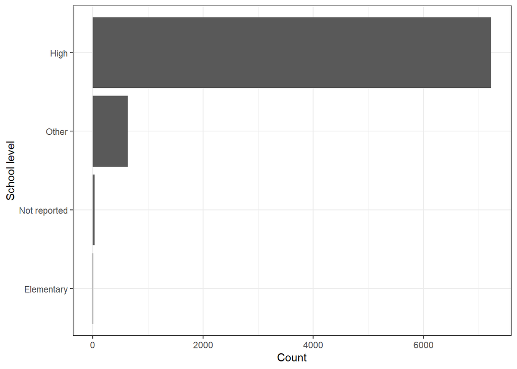

```r
edgap %>%
  count(school_level) %>%
  mutate(school_level = fct_reorder(school_level, n)) %>%
  ggplot(aes(x = school_level, y = n)) +
  geom_col() +
  coord_flip() +
  labs(x = "School level", y = "Count") +
  theme_bw()
```

$\rightarrow$ Modify the `edgap` data frame to include only the schools that are high schools.

```r
edgap <- edgap %>%
  filter(school_level == 'High')
edgap %>%
  count(school_level) %>%
  mutate(proportion = round(n/sum(n),3))
```

```
## # A tibble: 1 × 3
##   school_level     n proportion
##   <chr>        <int>      <dbl>
## 1 High          7230          1
```

## Exploratory data analysis

We have two main goals when doing exploratory data analysis. The first is that we want to understand the data set more completely. The second goal is to explore relationships between the variables to help guide the modeling process to answer our specific question.

### Graphical summaries

Make a pairs plot of the ACT scores and the socioeconomic variables. We will use the `ggpairs` function from the `GGally` package.

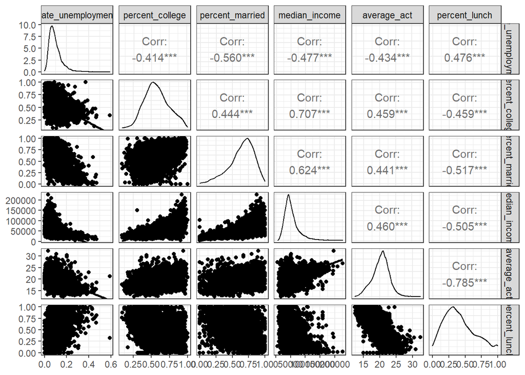

```r
#It may take a few seconds to produce the plot

edgap %>%
  select(-c(id,state,zip_code,school_type,school_level)) %>%
  ggpairs(lower = list(continuous=wrap("smooth"))) +
  theme_bw()
```

#### Distributions of individual numerical variables

$\rightarrow$ Describe the shape of the distribution of each variable.

We examine the density plots along the main diagonal of the pairs plots.

All distributions appear to be unimodal.

rate_unemployment has a positively skewed distribution. The values near 0.6 may be outliers.

percent_college has a roughly symmetric distribution.

percent_married has a negatively skewed distribution.

average_act has an approximately normal distribution. This is not surprising for a distribution of averages.

median_income has a positively skewed distribution, which is what you expect for income distributions.

percent_lunch has a slightly positively skewed distribution.

#### Categorical variables

What states are present in the data set and with what frequency?

$\rightarrow$ First find the states present.

```r
edgap %>%
  select(state) %>%
  unique()
```

```
## # A tibble: 20 × 1
##    state
##    <chr>
##  1 DE
##  2 FL
##  3 GA
##  4 IL
##  5 IN
##  6 KY
##  7 LA
##  8 MA
##  9 MI
## 10 MO
## 11 NJ
## 12 NY
## 13 NC
## 14 OH
## 15 PA
## 16 TN
## 17 TX
## 18 WA
## 19 WI
## 20 WY
```

$\rightarrow$ Now count the observations by state. Display the results as a bar graph.

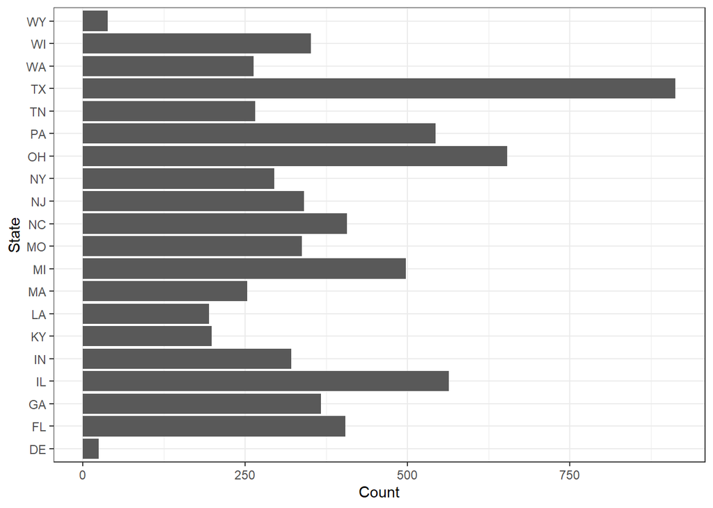

```r
edgap %>%
  count(state) %>%
  ggplot(aes(x = state, y = n)) +
  geom_col() +
  coord_flip() +
  labs(x = "State", y = "Count") +
  theme_bw()
```

$\rightarrow$ Reorder the states by count using `fct_reorder`

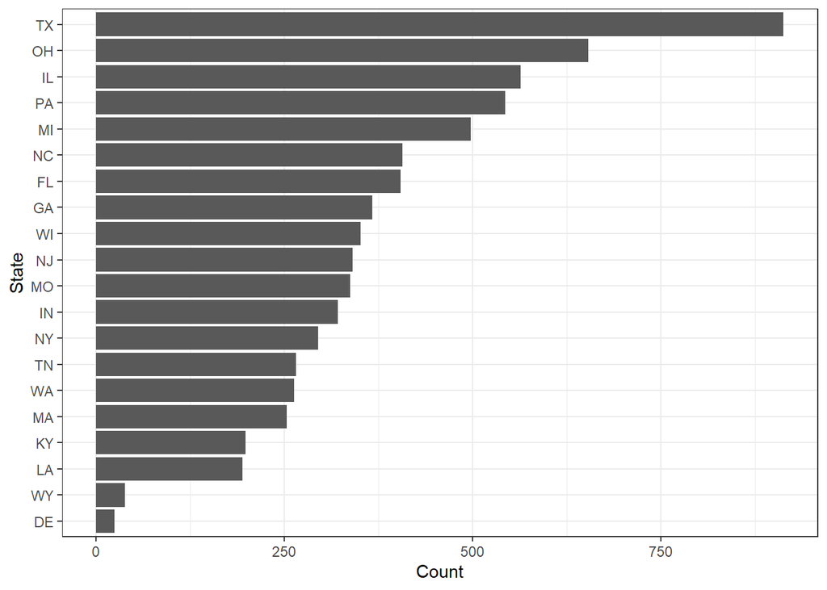

```r
edgap %>%
  count(state) %>%
  mutate(state = fct_reorder(state, n)) %>%
  ggplot(aes(x = state, y = n)) +
  geom_col() +
  coord_flip() +
  labs(x = "State", y = "Count") +
  theme_bw()
```

$\rightarrow$ What school types are present in the data set and with what frequency? Present the results as a table and as a bar graph.

```r
edgap %>%
  count(school_type) %>%
  mutate(proportion = round(n/sum(n),3))
```

```
## # A tibble: 4 × 3
##   school_type                     n proportion
##   <chr>                       <int>      <dbl>
## 1 Alternative School              9      0.001
## 2 Career and Technical School     1      0
## 3 Regular School               7218      0.998
## 4 Special Education School        2      0
```